# Práctica de Estadística descriptiva

Javier Herráez Albarrán

15/1/2022

## **Ejercicio 2**

En este ejercicio usaremos el dataset de BostonHousing con datos de viviendas en Boston. Las variables que contiene el dataset son las siguientes:

- **crim:** per capita crime rate by town
- **zn:** proportion of residential land zoned for lots over 25,000 sq.ft
- **indus:** proportion of non-retail business acres per town
- **chas:** Charles River dummy variable (= 1 if tract bounds river; 0 otherwise)
- **nox:** nitric oxides concentration (parts per 10 million)
- **rm:** average number of rooms per dwelling
- **age:** proportion of owner-occupied units built prior to 1940
- **dis:** weighted distances to five Boston employment centres
- **rad:** index of accessibility to radial highways
- **tax:** full-value property-tax rate per USD 10,000
- **ptratio:** pupil-teacher ratio by town
- **b:** 1000(B - 0.63)^2 where B is the proportion of blacks by town
- **lstat:** percentage of lower status of the population
- **medv:** median value of owner-occupied homes in USD 1000’s

```r
library(mlbench)
library(dplyr)
library(GGally) # ggplot2-based visualization of correlations
library(leaps)
library(lmtest)
library(regclass)
library(nortest)
library(car)
library(caret)
```

#### A. Realiza un análisis descriptivo completo de los datos.

Lo primero que haremos será analizar la forma de nuestro dataset, es decir, el número de observaciones y variables, además de los nombres de éstas.

```r
data(BostonHousing)
```

```r
# Cantidad total de filas
nrow(BostonHousing)
```

```
## [1] 506
```

```r
# Cantidad total de columnas
ncol(BostonHousing)
```

```
## [1] 14
```

```r
# Nombres de columnas
colnames(BostonHousing)
```

```
##  [1] "crim"    "zn"      "indus"   "chas"    "nox"     "rm"      "age"
##  [8] "dis"     "rad"     "tax"     "ptratio" "b"       "lstat"   "medv"
```

Echamos un vistazo a las primeras filas del dataset para hacernos una idea de su contenido.

```r
head(BostonHousing)
```

```
##      crim zn indus chas   nox    rm  age    dis rad tax ptratio      b lstat
## 1 0.00632 18  2.31    0 0.538 6.575 65.2 4.0900   1 296    15.3 396.90  4.98
## 2 0.02731  0  7.07    0 0.469 6.421 78.9 4.9671   2 242    17.8 396.90  9.14
## 3 0.02729  0  7.07    0 0.469 7.185 61.1 4.9671   2 242    17.8 392.83  4.03
## 4 0.03237  0  2.18    0 0.458 6.998 45.8 6.0622   3 222    18.7 394.63  2.94
## 5 0.06905  0  2.18    0 0.458 7.147 54.2 6.0622   3 222    18.7 396.90  5.33
## 6 0.02985  0  2.18    0 0.458 6.430 58.7 6.0622   3 222    18.7 394.12  5.21
##   medv
## 1 24.0
## 2 21.6
## 3 34.7
## 4 33.4
## 5 36.2
## 6 28.7
```

Analizamos las clases de nuestras variables, así como algunos de sus valores.

```r
str(BostonHousing)
```

```
## 'data.frame':    506 obs. of  14 variables:
##  $ crim   : num  0.00632 0.02731 0.02729 0.03237 0.06905 ...
##  $ zn     : num  18 0 0 0 0 0 12.5 12.5 12.5 12.5 ...
##  $ indus  : num  2.31 7.07 7.07 2.18 2.18 2.18 7.87 7.87 7.87 7.87 ...
##  $ chas   : Factor w/ 2 levels "0","1": 1 1 1 1 1 1 1 1 1 1 ...
##  $ nox    : num  0.538 0.469 0.469 0.458 0.458 0.458 0.524 0.524 0.524 0.524 ...
##  $ rm     : num  6.58 6.42 7.18 7 7.15 ...
##  $ age    : num  65.2 78.9 61.1 45.8 54.2 58.7 66.6 96.1 100 85.9 ...
##  $ dis    : num  4.09 4.97 4.97 6.06 6.06 ...
##  $ rad    : num  1 2 2 3 3 3 5 5 5 5 ...
##  $ tax    : num  296 242 242 222 222 222 311 311 311 311 ...
##  $ ptratio: num  15.3 17.8 17.8 18.7 18.7 18.7 15.2 15.2 15.2 15.2 ...
##  $ b      : num  397 397 393 395 397 ...
##  $ lstat  : num  4.98 9.14 4.03 2.94 5.33 ...
##  $ medv   : num  24 21.6 34.7 33.4 36.2 28.7 22.9 27.1 16.5 18.9 ...
```

Ejecutamos un summary para observar la información estadística de nuestro dataset.

```r
summary(BostonHousing)
```

```
##       crim                zn             indus       chas         nox
##  Min.   : 0.00632   Min.   :  0.00   Min.   : 0.46   0:471   Min.   :0.3850
##  1st Qu.: 0.08205   1st Qu.:  0.00   1st Qu.: 5.19   1: 35   1st Qu.:0.4490
##  Median : 0.25651   Median :  0.00   Median : 9.69           Median :0.5380
##  Mean   : 3.61352   Mean   : 11.36   Mean   :11.14           Mean   :0.5547
##  3rd Qu.: 3.67708   3rd Qu.: 12.50   3rd Qu.:18.10           3rd Qu.:0.6240
##  Max.   :88.97620   Max.   :100.00   Max.   :27.74           Max.   :0.8710
##        rm             age              dis              rad
##  Min.   :3.561   Min.   :  2.90   Min.   : 1.130   Min.   : 1.000
##  1st Qu.:5.886   1st Qu.: 45.02   1st Qu.: 2.100   1st Qu.: 4.000
##  Median :6.208   Median : 77.50   Median : 3.207   Median : 5.000
##  Mean   :6.285   Mean   : 68.57   Mean   : 3.795   Mean   : 9.549
##  3rd Qu.:6.623   3rd Qu.: 94.08   3rd Qu.: 5.188   3rd Qu.:24.000
##  Max.   :8.780   Max.   :100.00   Max.   :12.127   Max.   :24.000
##       tax           ptratio            b              lstat
##  Min.   :187.0   Min.   :12.60   Min.   :  0.32   Min.   : 1.73
##  1st Qu.:279.0   1st Qu.:17.40   1st Qu.:375.38   1st Qu.: 6.95
##  Median :330.0   Median :19.05   Median :391.44   Median :11.36
##  Mean   :408.2   Mean   :18.46   Mean   :356.67   Mean   :12.65
##  3rd Qu.:666.0   3rd Qu.:20.20   3rd Qu.:396.23   3rd Qu.:16.95
##  Max.   :711.0   Max.   :22.00   Max.   :396.90   Max.   :37.97
##       medv
##  Min.   : 5.00
##  1st Qu.:17.02
##  Median :21.20
##  Mean   :22.53
##  3rd Qu.:25.00
##  Max.   :50.00
```

Buscamos si existe alguna fila repetida para eleimirla en tal caso.

```r
count(BostonHousing[duplicated(BostonHousing),])
```

```
##   n
## 1 0
```

No existe ninguna fila repetida.

El siguiente paso será realizar gráficos para ver la relación entre las distintas variables y medv, que es la variable que nos interesa.

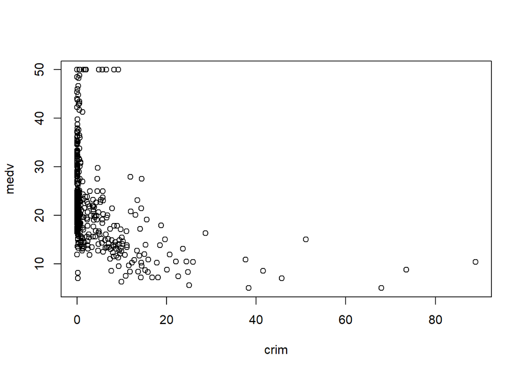

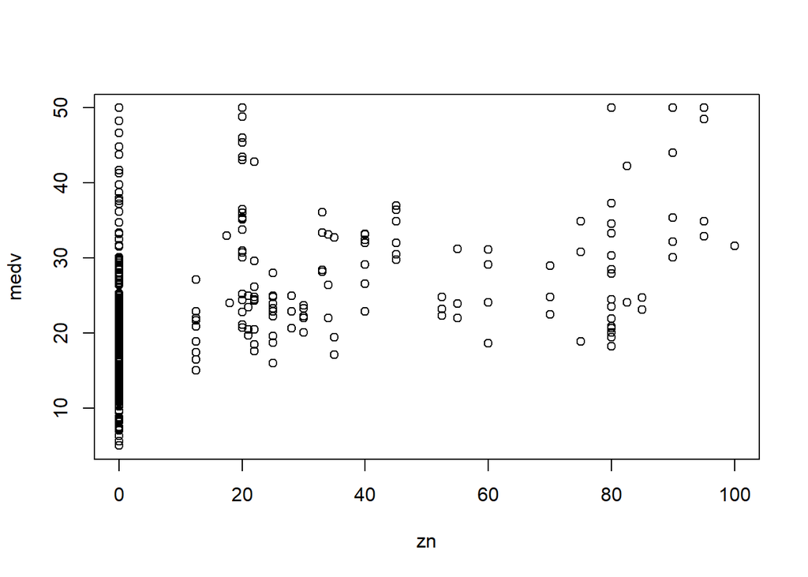

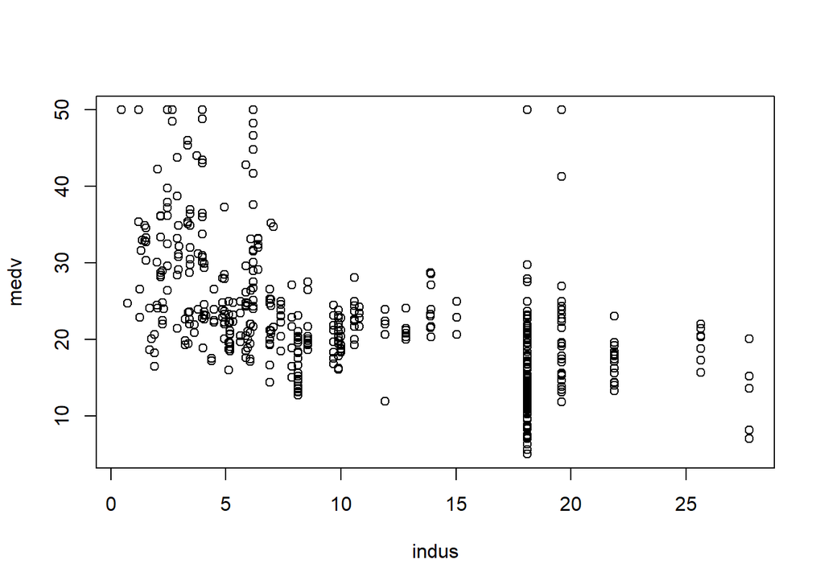

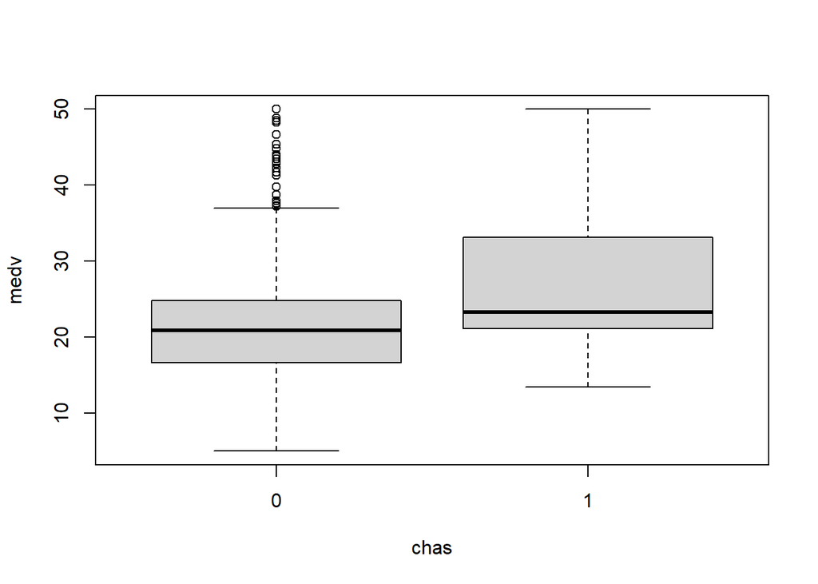

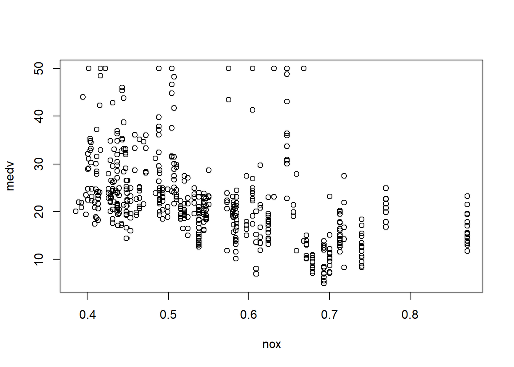

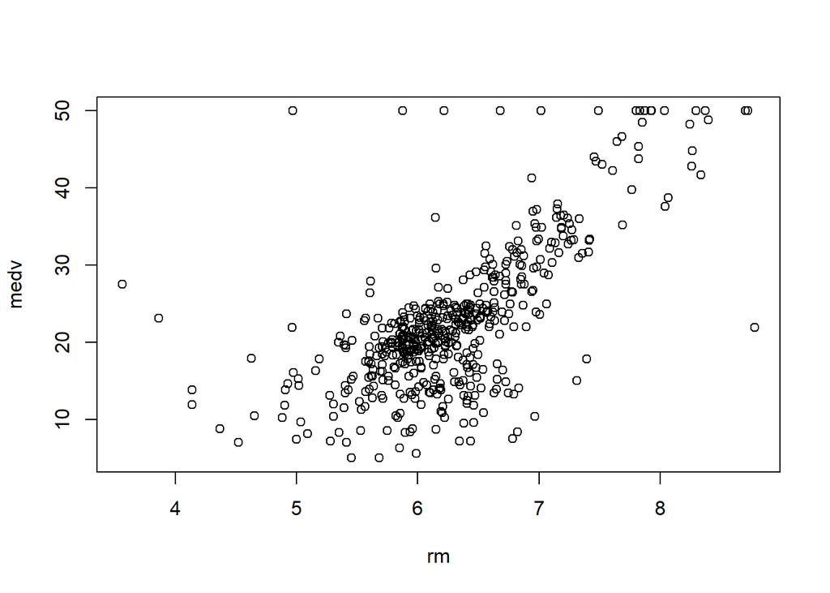

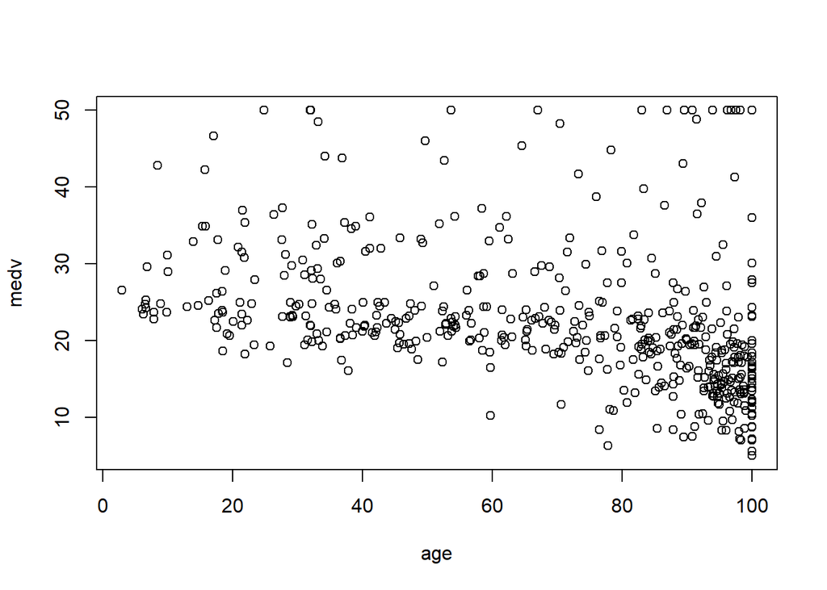

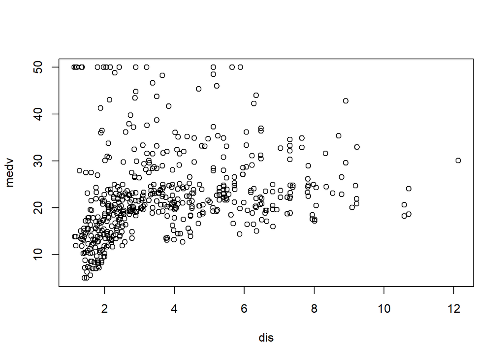

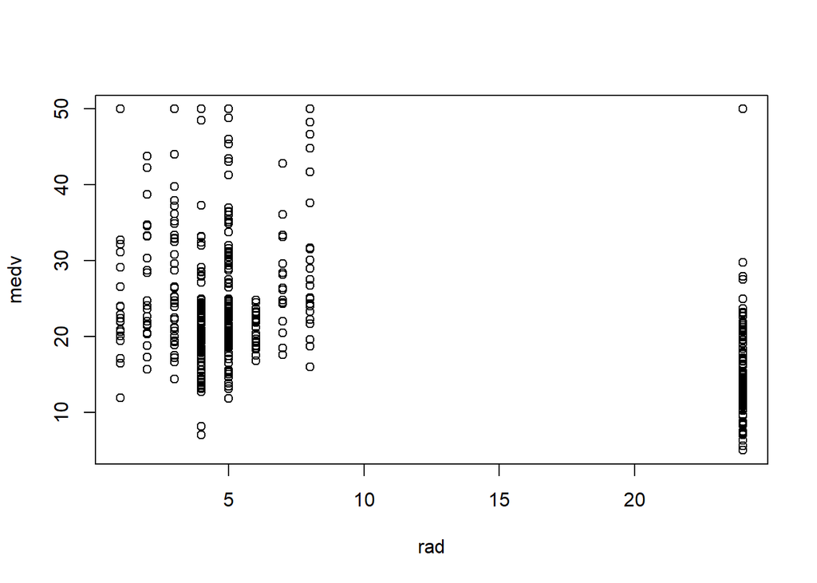

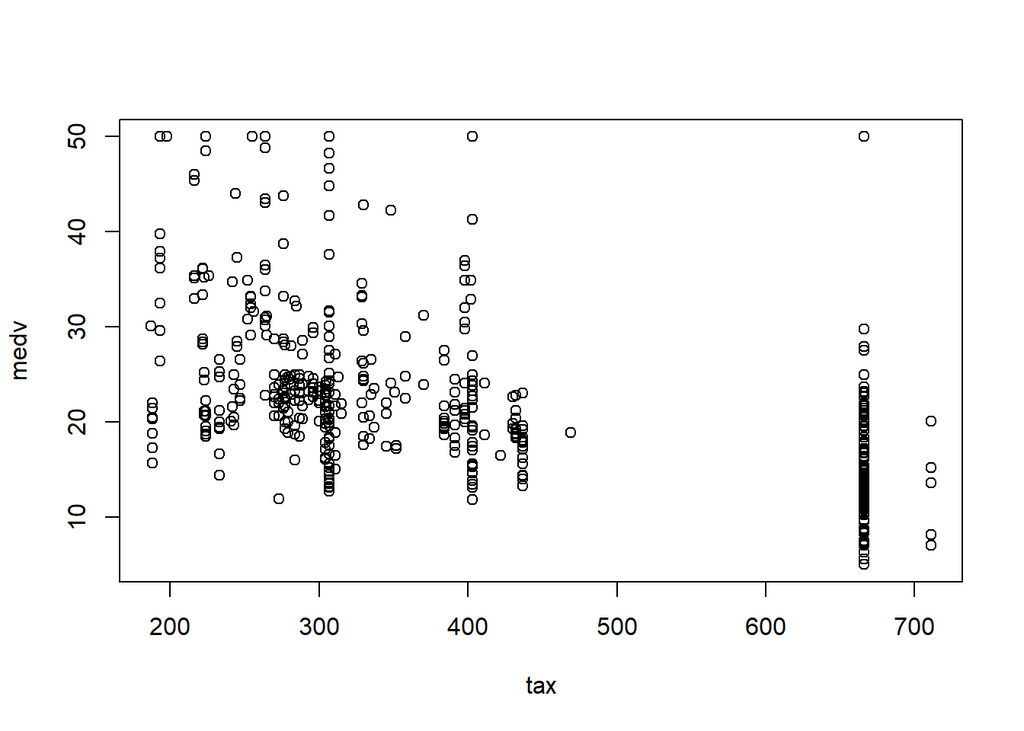

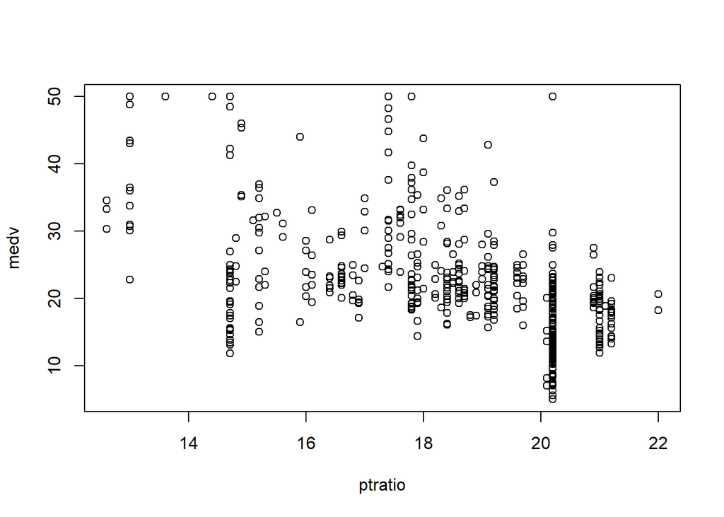

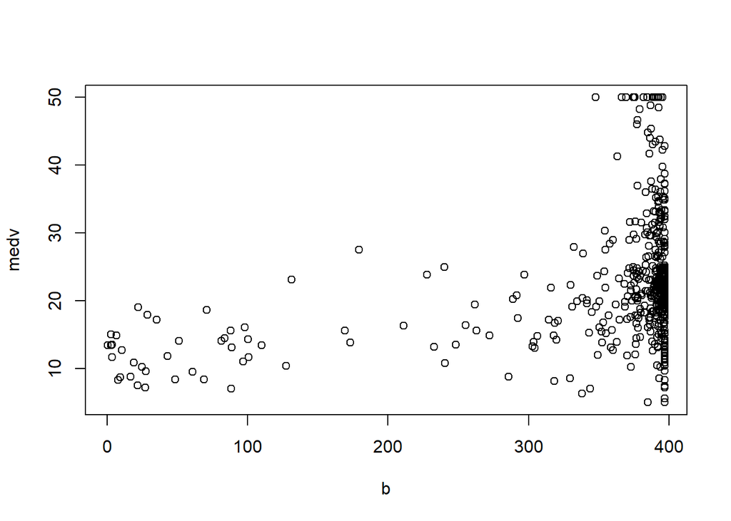

[1 more figures not shown]

```r
for(i in 1:ncol(BostonHousing)){
  if(colnames(BostonHousing)[i] != "medv"){
    plot(BostonHousing[,i], BostonHousing$medv, type='p', xlab=names(BostonHousing)[i], ylab="medv")
  }
}
```

Además, dibujaremos un histograma para ver la distribución de medv.

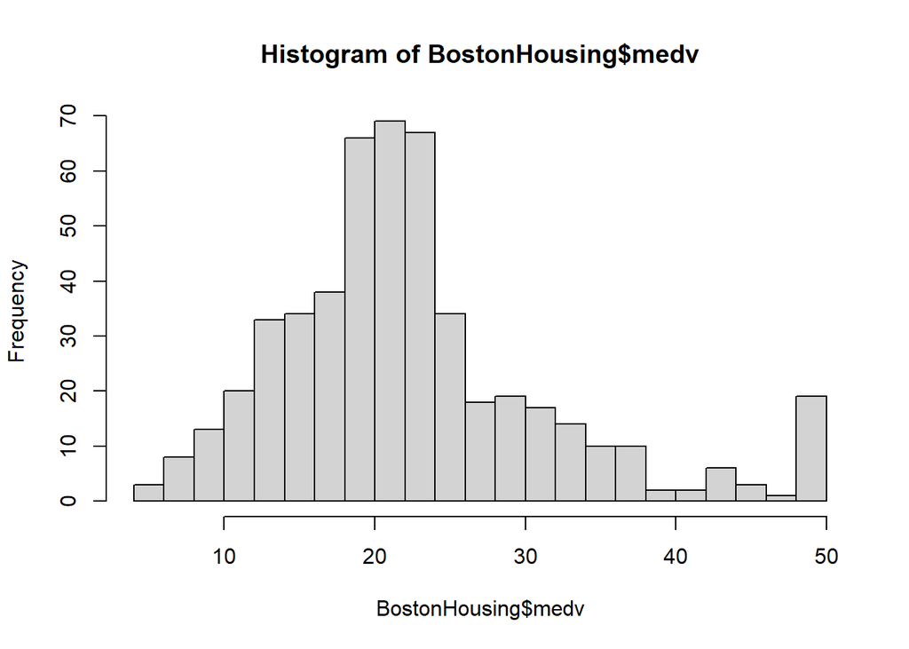

```r
hist(BostonHousing$medv, breaks = 20)
```

Por último, veremos la matriz de correlación entre todas las variables (a excepción de chas que es un factor)

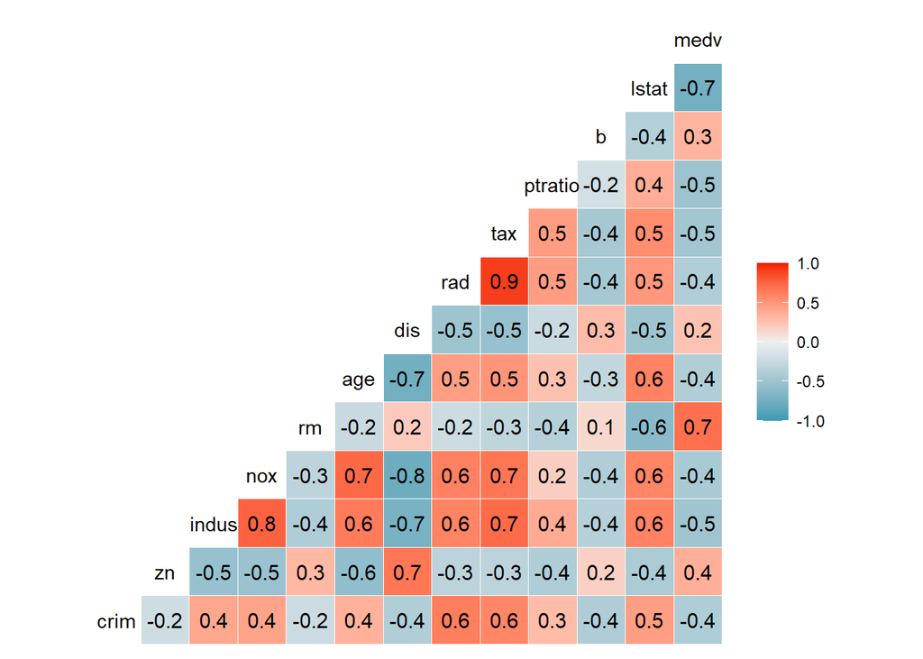

```r
ggcorr(BostonHousing, label = TRUE)
```

#### B. Construye un modelo de regresión lineal que permite predecir medv (debes realizar el análisis completo: desde un modelo inicial hasta el ajuste del modelo final y la presentación de resultados, pasando por los diferentes pasos que te permitan optimizar tu primer modelo, así como comprobar si verifican o no las hipótesis en las que se fundamentan los modelos de regresión lineal).

Lo primero que haremos será probar *best subset selection* para construir el modelo.

```r
model <- regsubsets(medv ~ . , data = BostonHousing, nvmax = ncol(BostonHousing))
model_sumary <- summary(model)
model_sumary
```

```
## Subset selection object
## Call: regsubsets.formula(medv ~ ., data = BostonHousing, nvmax = ncol(BostonHousing))
## 13 Variables  (and intercept)
##         Forced in Forced out
## crim        FALSE      FALSE
## zn          FALSE      FALSE
## indus       FALSE      FALSE
## chas1       FALSE      FALSE
## nox         FALSE      FALSE
## rm          FALSE      FALSE
## age         FALSE      FALSE
## dis         FALSE      FALSE
## rad         FALSE      FALSE
## tax         FALSE      FALSE
## ptratio     FALSE      FALSE
## b           FALSE      FALSE
## lstat       FALSE      FALSE
## 1 subsets of each size up to 13
## Selection Algorithm: exhaustive
##           crim zn  indus chas1 nox rm  age dis rad tax ptratio b   lstat
## 1  ( 1 )  " "  " " " "   " "   " " " " " " " " " " " " " "     " " "*"
## 2  ( 1 )  " "  " " " "   " "   " " "*" " " " " " " " " " "     " " "*"
## 3  ( 1 )  " "  " " " "   " "   " " "*" " " " " " " " " "*"     " " "*"
## 4  ( 1 )  " "  " " " "   " "   " " "*" " " "*" " " " " "*"     " " "*"
## 5  ( 1 )  " "  " " " "   " "   "*" "*" " " "*" " " " " "*"     " " "*"
## 6  ( 1 )  " "  " " " "   "*"   "*" "*" " " "*" " " " " "*"     " " "*"
## 7  ( 1 )  " "  " " " "   "*"   "*" "*" " " "*" " " " " "*"     "*" "*"
## 8  ( 1 )  " "  "*" " "   "*"   "*" "*" " " "*" " " " " "*"     "*" "*"
## 9  ( 1 )  "*"  " " " "   "*"   "*" "*" " " "*" "*" " " "*"     "*" "*"
## 10  ( 1 ) "*"  "*" " "   " "   "*" "*" " " "*" "*" "*" "*"     "*" "*"
## 11  ( 1 ) "*"  "*" " "   "*"   "*" "*" " " "*" "*" "*" "*"     "*" "*"
## 12  ( 1 ) "*"  "*" "*"   "*"   "*" "*" " " "*" "*" "*" "*"     "*" "*"
## 13  ( 1 ) "*"  "*" "*"   "*"   "*" "*" "*" "*" "*" "*" "*"     "*" "*"
```

Veremos una serie de estadísticos para ver el error de predicción en función de las variables utilizadas en el modelo. Los estadíosticos serán:

- $R^2$

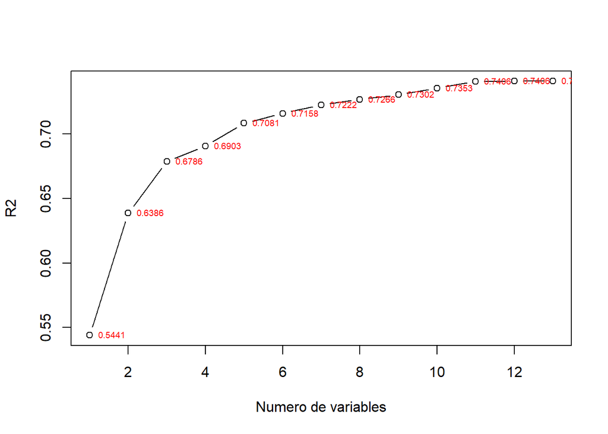

```r
# R2
plot(model_sumary$rsq, xlab = "Numero de variables", ylab = "R2", type = "b")
text(model_sumary$rsq,
     labels = round(model_sumary$rsq, 4),
     cex = 0.6, pos = 4, col = "red")
```

- $R^2 ajusted$

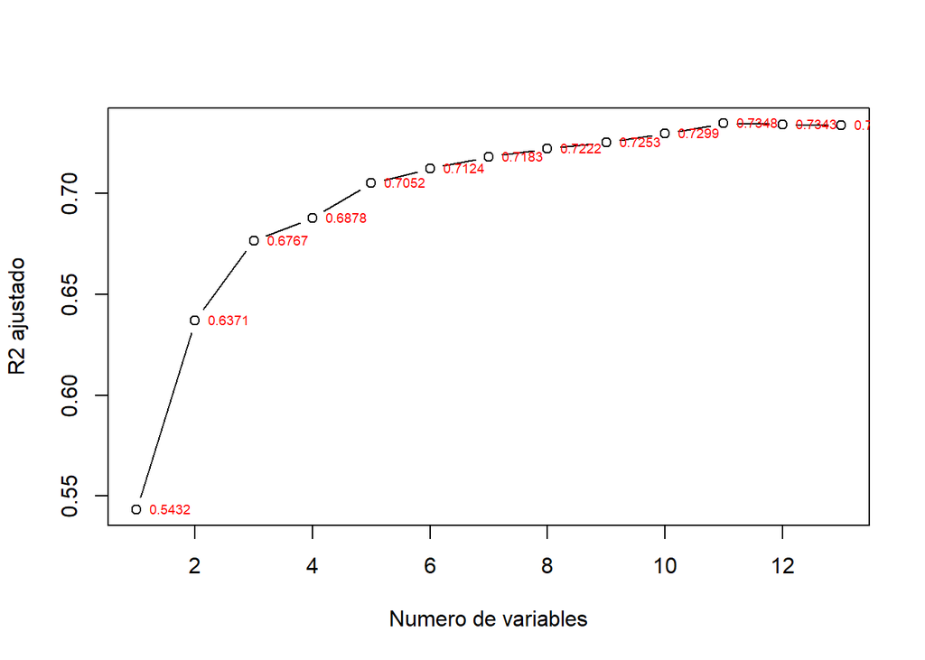

```r
# R2 ajustado
plot(model_sumary$adjr2, xlab = "Numero de variables", ylab = "R2 ajustado", type = "b")
text(model_sumary$adjr2,
     labels = round(model_sumary$adjr2, 4),
     cex = 0.6, pos = 4, col = "red")
```

- *Criterio de información Bayesiana (BIC)*

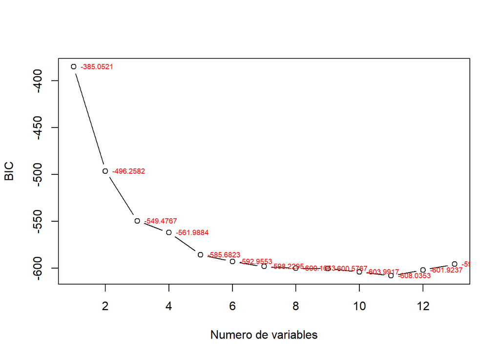

```r
# BIC
plot(model_sumary$bic, xlab = "Numero de variables", ylab = "BIC", type = "b")
text(model_sumary$bic,
     labels = round(model_sumary$bic, 4),
     cex = 0.6, pos = 4, col = "red")
```

- *Estadístico* $C_{p}$ *de Mallows:*

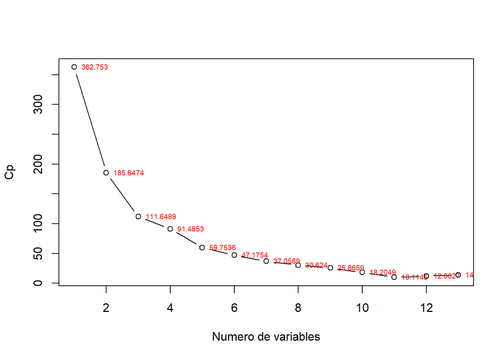

```r
# Cp Mallows
plot(model_sumary$cp, xlab = "Numero de variables", ylab = "Cp", type = "b")
text(model_sumary$cp,
     labels = round(model_sumary$cp, 4),
     cex = 0.6, pos = 4, col = "red")
```

- *Criterio de información de Akaike (AIC):*

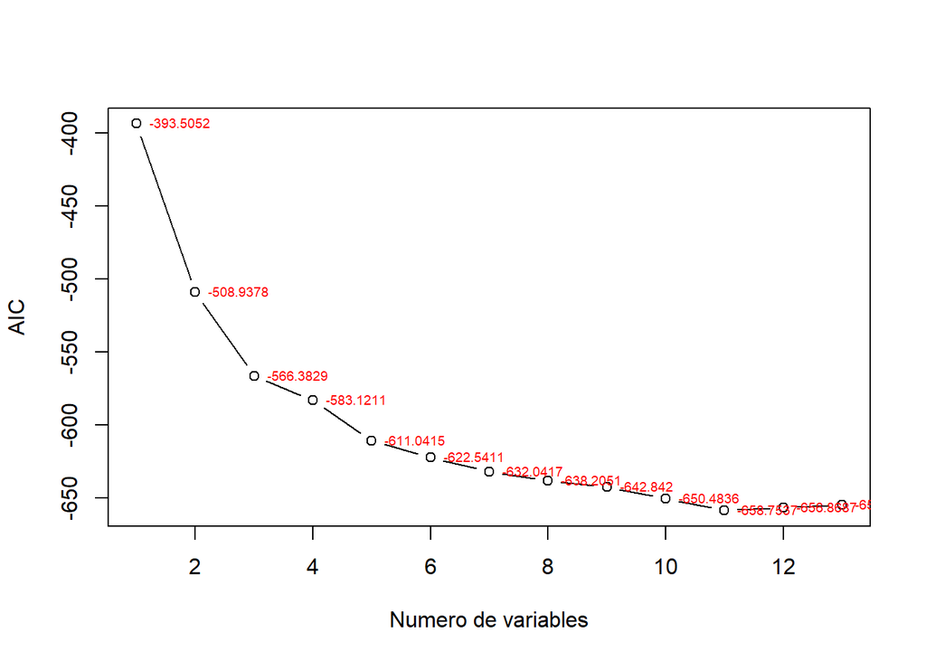

```r
# AIC
n <- nrow(BostonHousing)
p <- apply(model_sumary$which, 1, sum)
aic <- model_sumary$bic - log(n) * p + 2 * p
plot(aic, xlab = "Numero de variables", ylab = "AIC", type = "b")
text(aic,
     labels = round(aic, 4),
     cex = 0.6, pos = 4, col = "red")
```

Por el criterio del codo elegimos probar con11 variables aunque parezcan bastantes. Procedemos entonces a ajustar un modelo con las variables seleccionadas.

```r
lm_medv <- lm(medv ~ crim + zn + chas + nox + rm + dis + rad + tax + ptratio + b + lstat, data = BostonHousing)
summary(lm_medv)
```

```
##
## Call:
## lm(formula = medv ~ crim + zn + chas + nox + rm + dis + rad +
##     tax + ptratio + b + lstat, data = BostonHousing)
##
## Residuals:
##      Min       1Q   Median       3Q      Max
## -15.5984  -2.7386  -0.5046   1.7273  26.2373
##
## Coefficients:
##               Estimate Std. Error t value Pr(>|t|)
## (Intercept)  36.341145   5.067492   7.171 2.73e-12 ***
## crim         -0.108413   0.032779  -3.307 0.001010 **
## zn            0.045845   0.013523   3.390 0.000754 ***
## chas1         2.718716   0.854240   3.183 0.001551 **
## nox         -17.376023   3.535243  -4.915 1.21e-06 ***
## rm            3.801579   0.406316   9.356  < 2e-16 ***
## dis          -1.492711   0.185731  -8.037 6.84e-15 ***
## rad           0.299608   0.063402   4.726 3.00e-06 ***
## tax          -0.011778   0.003372  -3.493 0.000521 ***
## ptratio      -0.946525   0.129066  -7.334 9.24e-13 ***
## b             0.009291   0.002674   3.475 0.000557 ***
## lstat        -0.522553   0.047424 -11.019  < 2e-16 ***
## ---
## Signif. codes:  0 '***' 0.001 '**' 0.01 '*' 0.05 '.' 0.1 ' ' 1
##
## Residual standard error: 4.736 on 494 degrees of freedom
## Multiple R-squared:  0.7406, Adjusted R-squared:  0.7348
## F-statistic: 128.2 on 11 and 494 DF,  p-value: < 2.2e-16
```

Vemos que todas las variables parecen tener una relación significativa con la variable respuesta aunque el $R^2 ajusted$ del modelo podría ser mejor.

Representamos los residuos del modelo.

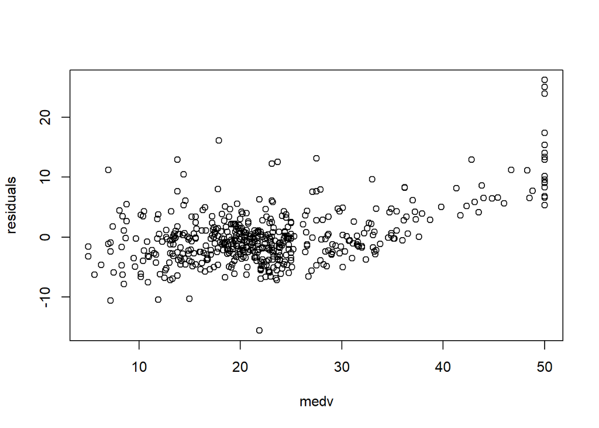

```r
plot(BostonHousing$medv, lm_medv$residuals, xlab='medv', ylab='residuals')
```

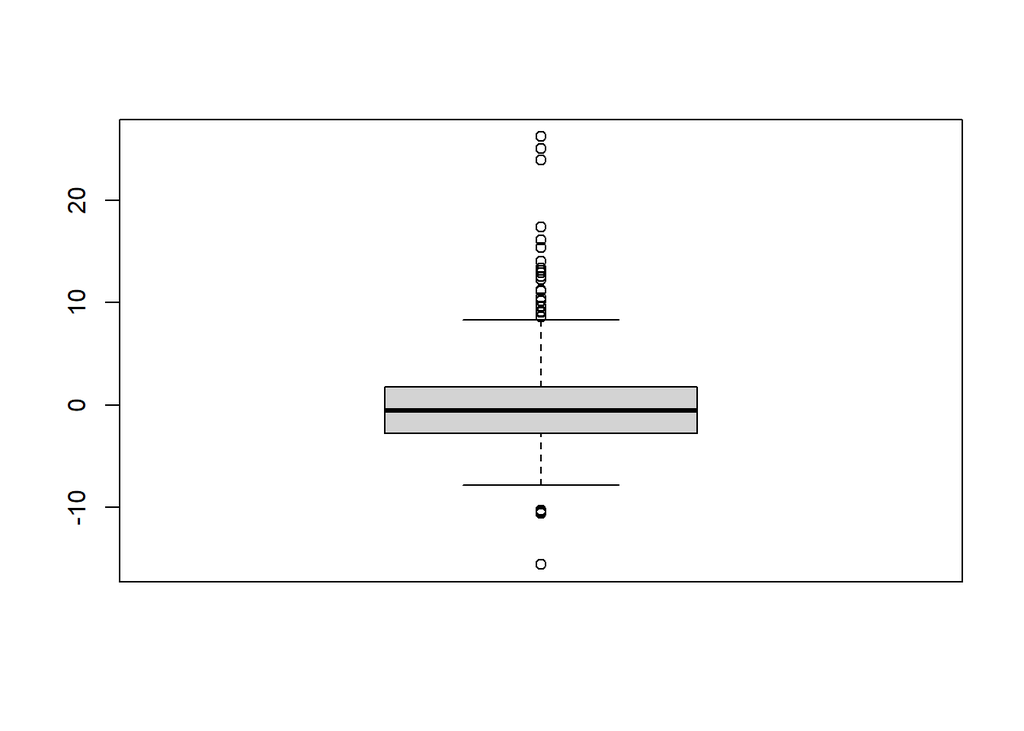

```r
boxplot(lm_medv$residuals)
```

Excepto por la gran cantidad de outliers en valores altos de medv, el diagrama de residuos es el esperado.

A la hora de dibujar las variables enfrentadas con medv, hemos podido ver que la variable lstat parece que tenía una correlación negativa con medv. Podemos utilizar su inversa en el modelo y ver su resultado.

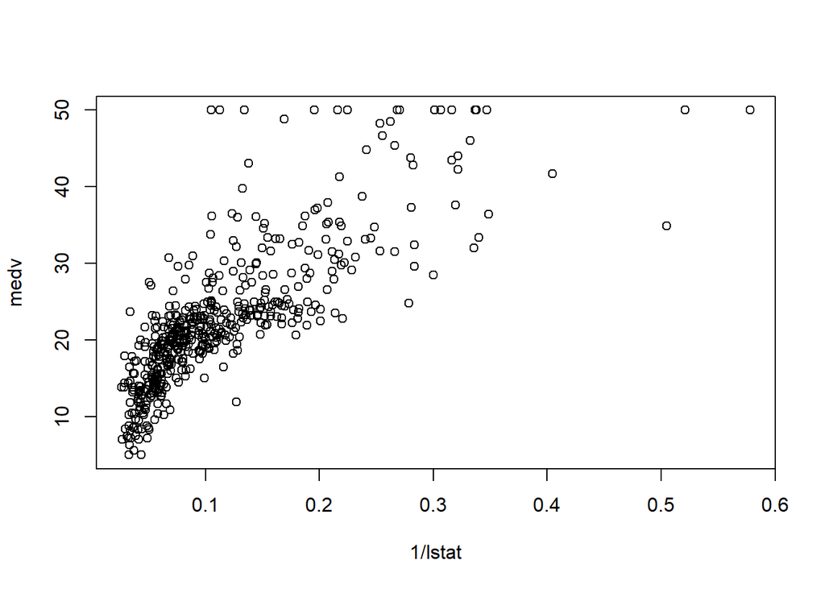

```r
plot(1/BostonHousing$lstat, BostonHousing$medv, type='p', xlab="1/lstat", ylab="medv")
```

```r
lm_medv_inv_lstat <- update(lm_medv, . ~ . + I(1/lstat))
summary(lm_medv_inv_lstat)
```

```
##
## Call:
## lm(formula = medv ~ crim + zn + chas + nox + rm + dis + rad +
##     tax + ptratio + b + lstat + I(1/lstat), data = BostonHousing)
##
## Residuals:
##      Min       1Q   Median       3Q      Max
## -13.8138  -2.5043  -0.2339   1.7717  26.4381
##
## Coefficients:
##               Estimate Std. Error t value Pr(>|t|)
## (Intercept)  31.179652   4.542150   6.865 2.01e-11 ***
## crim         -0.138584   0.029354  -4.721 3.06e-06 ***
## zn            0.014598   0.012371   1.180 0.238583
## chas1         1.951114   0.764826   2.551 0.011041 *
## nox         -15.223145   3.158472  -4.820 1.92e-06 ***
## rm            2.641434   0.376569   7.014 7.65e-12 ***
## dis          -1.259164   0.166915  -7.544 2.22e-13 ***
## rad           0.298884   0.056542   5.286 1.88e-07 ***
## tax          -0.011779   0.003007  -3.917 0.000102 ***
## ptratio      -0.856745   0.115374  -7.426 4.97e-13 ***
## b             0.008732   0.002385   3.661 0.000279 ***
## lstat        -0.210168   0.050500  -4.162 3.73e-05 ***
## I(1/lstat)   48.641575   4.297013  11.320  < 2e-16 ***
## ---
## Signif. codes:  0 '***' 0.001 '**' 0.01 '*' 0.05 '.' 0.1 ' ' 1
##
## Residual standard error: 4.224 on 493 degrees of freedom
## Multiple R-squared:  0.7941, Adjusted R-squared:  0.7891
## F-statistic: 158.4 on 12 and 493 DF,  p-value: < 2.2e-16
```

Vemos que el valor del $R^2 ajusted$ mejora notablemente, aunque vemos que en este modelo hay un par de variables que pierden relación con la variable objetivo, por lo que procedemos a eliminarlas del modelo.

```r
lm_medv_inv_lstat <- update(lm_medv_inv_lstat, . ~ . - zn - chas)
summary(lm_medv_inv_lstat)
```

```
##
## Call:
## lm(formula = medv ~ crim + nox + rm + dis + rad + tax + ptratio +
##     b + lstat + I(1/lstat), data = BostonHousing)
##
## Residuals:
##     Min      1Q  Median      3Q     Max
## -12.458  -2.483  -0.315   1.813  27.303
##
## Coefficients:
##               Estimate Std. Error t value Pr(>|t|)
## (Intercept)  31.359477   4.567774   6.865 1.99e-11 ***
## crim         -0.140882   0.029395  -4.793 2.18e-06 ***
## nox         -14.855504   3.152133  -4.713 3.18e-06 ***
## rm            2.681210   0.377641   7.100 4.36e-12 ***
## dis          -1.182171   0.143986  -8.210 1.93e-15 ***
## rad           0.305686   0.056551   5.405 1.01e-07 ***
## tax          -0.011768   0.002958  -3.978 7.97e-05 ***
## ptratio      -0.918724   0.109767  -8.370 5.95e-16 ***
## b             0.009037   0.002396   3.772 0.000182 ***
## lstat        -0.200787   0.050388  -3.985 7.77e-05 ***
## I(1/lstat)   50.681805   4.197452  12.074  < 2e-16 ***
## ---
## Signif. codes:  0 '***' 0.001 '**' 0.01 '*' 0.05 '.' 0.1 ' ' 1
##
## Residual standard error: 4.248 on 495 degrees of freedom
## Multiple R-squared:  0.7909, Adjusted R-squared:  0.7866
## F-statistic: 187.2 on 10 and 495 DF,  p-value: < 2.2e-16
```

Podemos observar que el $R^2 ajusted$ disminuye prácticamente nada y que ahora todas las variables están bien relacionadas con la variable objetivo.

Pasamos a ver los residuos.

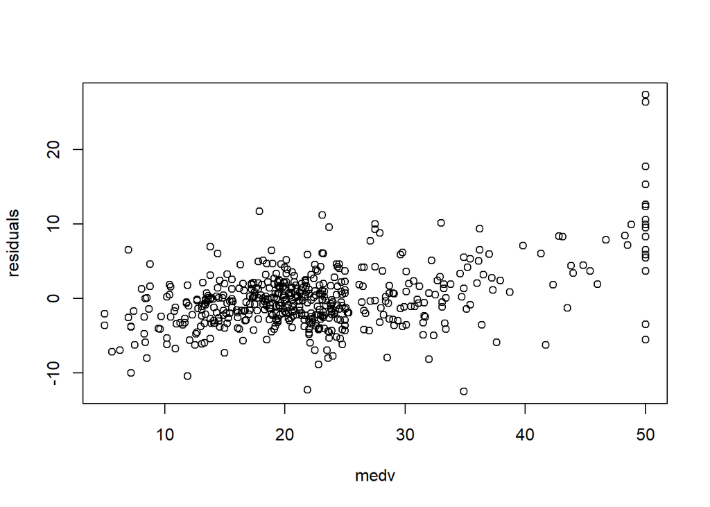

```r
plot(BostonHousing$medv, lm_medv_inv_lstat$residuals, xlab='medv', ylab='residuals')
```

Procedemos ahora a ver el leverage de los puntos.

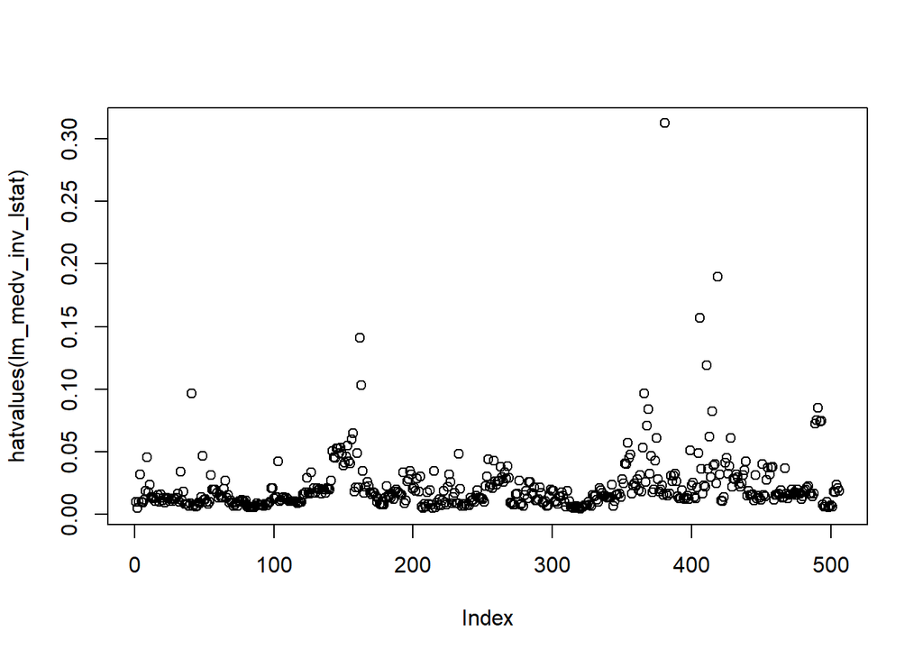

```r
plot(hatvalues(lm_medv_inv_lstat))
```

También lo podemos observar con la distancia de Cook.

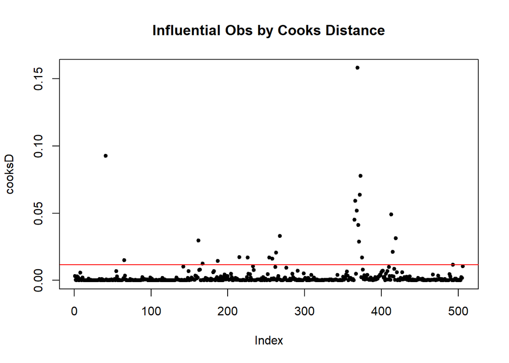

```r
cooksD <- cooks.distance(lm_medv_inv_lstat)
plot(cooksD, pch=20, main="Influential Obs by Cooks Distance")
abline(h = 4*mean(cooksD), col='red')
```

También, estudiaremos la colinealidad.

```r
VIF(lm_medv_inv_lstat)
```

```
##       crim        nox         rm        dis        rad        tax    ptratio
##   1.788769   3.733032   1.969926   2.572132   6.784133   6.953991   1.580112
##          b      lstat I(1/lstat)
##   1.338837   3.622646   2.945759
```

Observamos que hay ciertos valores algo sospechosos de colinealidad por lo que procedemos a eliminar uno de ellos. Además, eliminaremos también lstat ya que tenemos su inversa que tiene una relación más significativa con medv.

```r
lm_medv_candidate <- update(lm_medv_inv_lstat, . ~ . - tax - lstat)
summary(lm_medv_candidate)
```

```
##
## Call:
## lm(formula = medv ~ crim + nox + rm + dis + rad + ptratio + b +
##     I(1/lstat), data = BostonHousing)
##
## Residuals:
##      Min       1Q   Median       3Q      Max
## -14.3660  -2.3978  -0.2811   1.7329  28.7219
##
## Coefficients:
##               Estimate Std. Error t value Pr(>|t|)
## (Intercept)  23.800346   4.465812   5.329 1.50e-07 ***
## crim         -0.163315   0.029734  -5.493 6.33e-08 ***
## nox         -19.512219   3.136403  -6.221 1.05e-09 ***
## rm            3.266013   0.372950   8.757  < 2e-16 ***
## dis          -1.130655   0.147854  -7.647 1.07e-13 ***
## rad           0.126464   0.036991   3.419 0.000681 ***
## ptratio      -0.964659   0.112570  -8.569  < 2e-16 ***
## b             0.010640   0.002452   4.339 1.73e-05 ***
## I(1/lstat)   59.505571   3.651368  16.297  < 2e-16 ***
## ---
## Signif. codes:  0 '***' 0.001 '**' 0.01 '*' 0.05 '.' 0.1 ' ' 1
##
## Residual standard error: 4.381 on 497 degrees of freedom
## Multiple R-squared:  0.7767, Adjusted R-squared:  0.7731
## F-statistic: 216.1 on 8 and 497 DF,  p-value: < 2.2e-16
```

```r
VIF(lm_medv_candidate)
```

```
##       crim        nox         rm        dis        rad    ptratio          b
##   1.721276   3.475851   1.806913   2.550701   2.729909   1.562914   1.318532
## I(1/lstat)
##   2.096436
```

Con este modelo obtenemos que el $R^2 ajusted$ ha disminuido aunque muy poco pero ahora no tenemos variables con posible correlación. Parece que tenemos un modelo con el que trabajar.

Veamos sus gráficas.

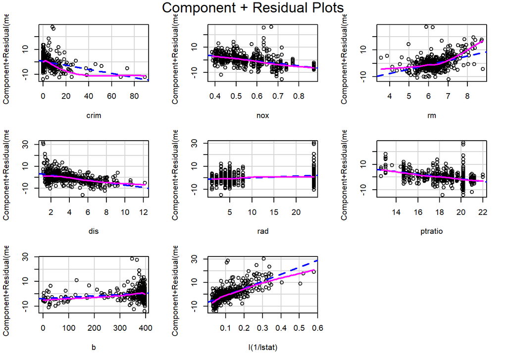

```r
crPlots(lm_medv_candidate)
```

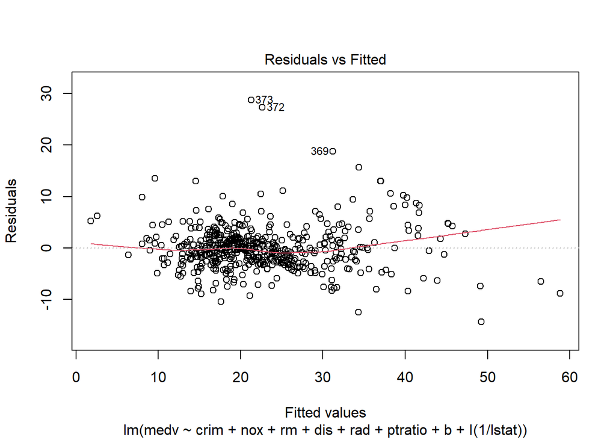

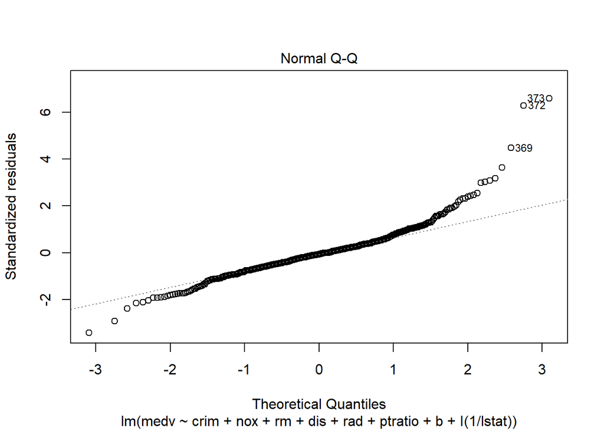

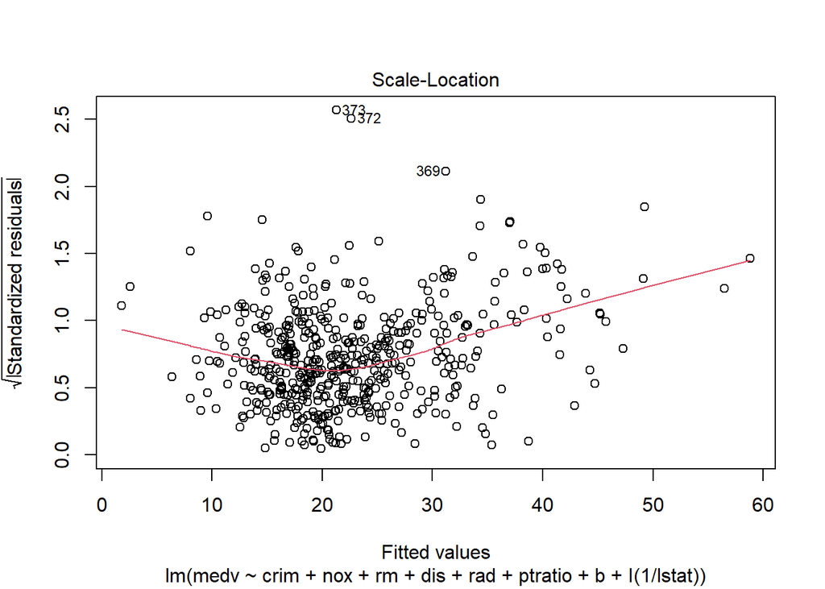

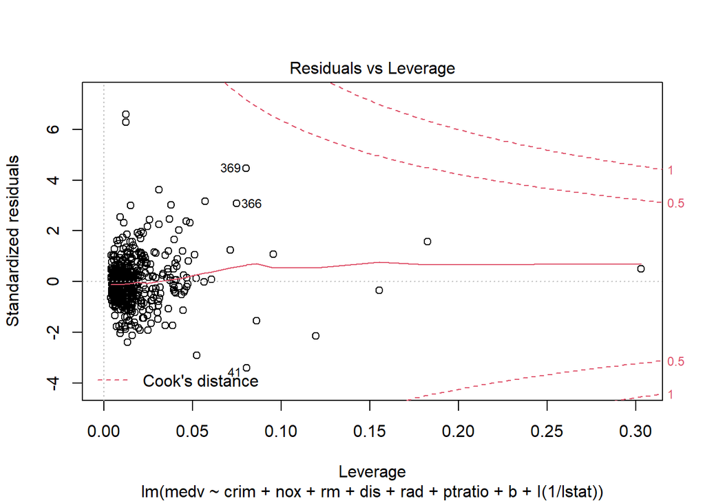

```r
plot(lm_medv_candidate)
```

Vamos a comprobar las hipótesis.

Primero estudiaremos si existe relación lineal entre las variables.

```r
raintest(lm_medv_candidate)
```

```
##
##  Rainbow test
##
## data:  lm_medv_candidate
## Rain = 0.71411, df1 = 253, df2 = 244, p-value = 0.996
```

```r
raintest(lm_medv)
```

```
##
##  Rainbow test
##
## data:  lm_medv
## Rain = 0.57816, df1 = 253, df2 = 241, p-value = 1
```

```r
raintest(lm_medv_inv_lstat)
```

```
##
##  Rainbow test
##
## data:  lm_medv_inv_lstat
## Rain = 0.63417, df1 = 253, df2 = 242, p-value = 0.9998
```

Probamos el resto de test empezando por comprobar si los residuos tienen media nula.

```r
t.test(lm_medv_candidate$residuals)
```

```
##
##  One Sample t-test
##
## data:  lm_medv_candidate$residuals
## t = 1.2898e-16, df = 505, p-value = 1
## alternative hypothesis: true mean is not equal to 0
## 95 percent confidence interval:
##  -0.379572  0.379572
## sample estimates:
##    mean of x
## 2.491865e-17
```

Podemos afirmar que la media de los residuos es nula, ya que el p-valor es igual a 1.

Para ver la existencia de homocedasticidad utilizamos el test de Breusch-Pagan.

```r
bptest(lm_medv_candidate)
```

```
##
##  studentized Breusch-Pagan test
##
## data:  lm_medv_candidate
## BP = 60.058, df = 8, p-value = 4.54e-10
```

El p-valor es demasiado pequeño por lo que rechazamos la homocedasticidad del modelo.

Para estudiar si los residuos tienen autocorrelación nula utilizamos el Durbin-Watson test.

```r
dwtest(lm_medv_candidate)
```

```
##
##  Durbin-Watson test
##
## data:  lm_medv_candidate
## DW = 1.1099, p-value < 2.2e-16
## alternative hypothesis: true autocorrelation is greater than 0
```

El p-valor es pequeño, entonces decimos que nuestros errores no son independientes.

Por último para estudiar la normalidad de los errores utilizamos los test de Shapiro-Wilk y de Anderson-Darling.

```r
shapiro.test(lm_medv_candidate$residuals)
```

```
##
##  Shapiro-Wilk normality test
##
## data:  lm_medv_candidate$residuals
## W = 0.90852, p-value < 2.2e-16
```

```r
ad.test(lm_medv_candidate$residuals)
```

```
##
##  Anderson-Darling normality test
##
## data:  lm_medv_candidate$residuals
## A = 7.7715, p-value < 2.2e-16
```

En ambos, el p-valor es muy pequeño por lo que podemos decir que no nos encontramos con errores distribuidos de forma normal.

## **Ejercicio 3**

#### En la construcción del modelo del ejercicio anterior habrás pasado por varios modelos intermedios. Considera el modelo final y un par de esos modelos intermedios y, mediante leave-one-out cross-validation y 10-fold cross-validation, estima su capacidad predictiva en situaciones reales y justifica si tu elección en el ejercicio anterior ha sido acertada o no.

### Leave-one-out cross-validation

```r
err_lm_medv <- c()
err_lm_medv_inv_lstat <- c()
err_lm_medv_candidate <- c()

for(i in 1:nrow(BostonHousing)){
  lm_medv.LOOCV <- update(lm_medv, data = BostonHousing[-i,])
  lm_medv_inv_lstat.LOOCV <- update(lm_medv_inv_lstat, data = BostonHousing[-i,])
  lm_medv_candidate.LOOCV <- update(lm_medv_candidate, data = BostonHousing[-i,])
  err_lm_medv <- c(err_lm_medv, (BostonHousing$medv[i] - predict(lm_medv.LOOCV, BostonHousing[i,]))**2)
  err_lm_medv_inv_lstat <- c(err_lm_medv_inv_lstat,  (BostonHousing$medv[i] - predict(lm_medv_inv_lstat.LOOCV, BostonHousing[i,]))**2)
  err_lm_medv_candidate <- c(err_lm_medv_candidate,  (BostonHousing$medv[i] - predict(lm_medv_candidate.LOOCV, BostonHousing[i,]))**2)
}
mean(err_lm_medv)
```

```
## [1] 23.51325
```

```r
mean(err_lm_medv_inv_lstat)
```

```
## [1] 18.7814
```

```r
mean(err_lm_medv_candidate)
```

```
## [1] 19.92304
```

Calculamos para todas las observaciones el MSE y estimamos el error del test mediante su media.

Podemos observar que la media del error cuadrático medio es menor en el segundo modelo, el *lm_medv_inv_lstat*, aunque bastante cercano al último, el *lm_medv_candidate*.

### 10-fold cross-validation

```r
fold_index_list <- createFolds(BostonHousing$medv, k = 10)

mat <- matrix(nrow = 0, ncol = 6)
colnames(mat) <- c('mse_train_lm_medv', 'mse_test_lm_medv', 'mse_train_lm_medv_inv_lstat', 'mse_test_lm_medv_inv_lstat',
                   'mse_train_lm_medv_candidate', 'mse_test_lm_medv_candidate')
for(fold in fold_index_list){
  training_data <- BostonHousing[-fold, ]
  test_data <- BostonHousing[fold, ]
  lm_medv.10_fold_CV <- update(lm_medv, data = training_data)
  lm_medv_inv_lstat.10_fold_CV <- update(lm_medv_inv_lstat, data = training_data)
  lm_medv_candidate.10_fold_CV <- update(lm_medv_candidate, data = training_data)
  mse_train_lm_medv <- mean((lm_medv.10_fold_CV$residuals)**2)
  mse_train_lm_medv_inv_lstat <- mean((lm_medv_inv_lstat.10_fold_CV$residuals)**2)
  mse_train_lm_medv_candidate <- mean((lm_medv_candidate.10_fold_CV$residuals)**2)
  mse_test_lm_medv <- mean((test_data$medv - predict(lm_medv.10_fold_CV, test_data))**2)
  mse_test_lm_medv_inv_lstat <- mean((test_data$medv - predict(lm_medv_inv_lstat.10_fold_CV, test_data))**2)
  mse_test_lm_medv_candidate <- mean((test_data$medv - predict(lm_medv_candidate.10_fold_CV, test_data))**2)
  mat <- rbind(mat, c(mse_train_lm_medv,
                      mse_test_lm_medv,
                      mse_train_lm_medv_inv_lstat,
                      mse_test_lm_medv_inv_lstat,
                      mse_train_lm_medv_candidate,
                      mse_test_lm_medv_candidate))
}

mat <- as.data.frame(mat)
colMeans(mat)
```

```
##           mse_train_lm_medv            mse_test_lm_medv
##                    21.82784                    23.24651
## mse_train_lm_medv_inv_lstat  mse_test_lm_medv_inv_lstat
##                    17.59914                    18.78311
## mse_train_lm_medv_candidate  mse_test_lm_medv_candidate
##                    18.79981                    19.83830
```

Para cada fold se ha estimado el error cuadrático medio y con todos ellos se calcula su media para estimar el error del test.

Volvemos a ver que el segundo modelo vuelve a tener un MSE más bajo que el resto, aunque otra vez cercano al del último modelo.

Podemos concluir entonces que hemos elegido bien el modelo ya que los errores que obtenemos son bastantes similares a la vez que nos libramos de los posibles problemas de correlación que teníamos en el segundo modelo.